# SDK_BehaviorOphysSession_and_BehaviorSession_loading

1. Loading modules
2. Behavior Ophys Sessions  
   2.1 loading dataset  
   2.2 dataset attributes
3. Behavior Sessions  
   3.1 loading dataset  
   3.2 dataset attributes

## Loading Modules

```python
import os
import pandas as pd
import matplotlib.pyplot as plt
```

SDK modules

```python
import visual_behavior.data_access.loading as loading #only needed for getting initial exp list

from allensdk.brain_observatory.behavior.behavior_session import BehaviorSession
from allensdk.brain_observatory.behavior.behavior_ophys_session import BehaviorOphysSession
```

## Behavior Ophys Sessions

get some experiment IDs to pick from

```python
#2/25/2021 need to be on dev branch of visual behavior to use the release_data_only=True
release_exps = loading.get_filtered_ophys_experiment_table(release_data_only=True).reset_index()
exps_list = release_exps["ophys_experiment_id"].unique()
```

#### load dataset

pick one experiment id and load the dataset for it

```python
ophys_experiment_id = exps_list[88]
print("ophys_experiment_id:", ophys_experiment_id)
dataset = BehaviorOphysSession.from_lims(ophys_experiment_id)
```

```
ophys_experiment_id: 880961028
```

### dataset attributes

two different methods for seeing what attributes and methods are attached to a dataset

- . **dict**
- list_api_methods()

```python
dataset.__dict__
```

```
{'api': <allensdk.brain_observatory.behavior.session_apis.data_io.behavior_ophys_lims_api.BehaviorOphysLimsApi at 0x1254f891588>,
 '_behavior_session_id': <allensdk.core.lazy_property.lazy_property.LazyProperty at 0x1254d9e37c8>,
 '_licks': <allensdk.core.lazy_property.lazy_property.LazyProperty at 0x1254e84c0c8>,
 '_rewards': <allensdk.core.lazy_property.lazy_property.LazyProperty at 0x1254e84c188>,
 '_running_speed': <allensdk.core.lazy_property.lazy_property.LazyProperty at 0x1254e84c248>,
 '_raw_running_speed': <allensdk.core.lazy_property.lazy_property.LazyProperty at 0x1254e84c1c8>,
 '_stimulus_presentations': <allensdk.core.lazy_property.lazy_property.LazyProperty at 0x1254f897988>,
 '_stimulus_templates': <allensdk.core.lazy_property.lazy_property.LazyProperty at 0x1254f8979c8>,
 '_stimulus_timestamps': <allensdk.core.lazy_property.lazy_property.LazyProperty at 0x1254f897948>,
 '_task_parameters': <allensdk.core.lazy_property.lazy_property.LazyProperty at 0x1254f897848>,
 '_trials': <allensdk.core.lazy_property.lazy_property.LazyProperty at 0x1254f897888>,
 '_metadata': <allensdk.core.lazy_property.lazy_property.LazyProperty at 0x1254f897788>,
 '_updated_params': set(),
 '_ignore': {'api'},
 '_eye_tracking_z_threshold': 3.0,
 '_eye_tracking_dilation_frames': 2,
 '_events_filter_scale': 2.0,
 '_events_filter_n_time_steps': 20,
 '_ophys_session_id': <allensdk.core.lazy_property.lazy_property.LazyProperty at 0x1254f8976c8>,
 '_ophys_experiment_id': <allensdk.core.lazy_property.lazy_property.LazyProperty at 0x1254f8977c8>,
 '_max_projection': <allensdk.core.lazy_property.lazy_property.LazyProperty at 0x1254f897708>,
 '_average_projection': <allensdk.core.lazy_property.lazy_property.LazyProperty at 0x1254f897608>,
 '_ophys_timestamps': <allensdk.core.lazy_property.lazy_property.LazyProperty at 0x1254f897648>,
 '_dff_traces': <allensdk.core.lazy_property.lazy_property.LazyProperty at 0x1254f897548>,
 '_events': <allensdk.core.lazy_property.lazy_property.LazyProperty at 0x1254f897588>,
 '_cell_specimen_table': <allensdk.core.lazy_property.lazy_property.LazyProperty at 0x1254f897488>,
 '_corrected_fluorescence_traces': <allensdk.core.lazy_property.lazy_property.LazyProperty at 0x1254f8974c8>,
 '_motion_correction': <allensdk.core.lazy_property.lazy_property.LazyProperty at 0x1254f8973c8>,
 '_segmentation_mask_image': <allensdk.core.lazy_property.lazy_property.LazyProperty at 0x1254f897408>,
 '_eye_tracking': <allensdk.core.lazy_property.lazy_property.LazyProperty at 0x1254f897308>,
 '_eye_tracking_rig_geometry': <allensdk.core.lazy_property.lazy_property.LazyProperty at 0x1254f897348>}
```

average_projection  
behavior_session_id  
cell_specimen_table  
corrected_fluorescence_traces  
dff_traces  
events  
eye_tracking  
eye_tracking_rig_geometry  
get_rolling_performance_df  
get_performance_metrics  
licks  
max_projection  
metadata  
motion_correction  
ophys_experiment_id  
ophys_session_id  
ophys_timestamps  
raw_running_speed  
rewards  
running_speed  
segmentation_mask_image  
stimulus_presentations  
stimulus_templates  
stimulus_timestamps  
task_parameters  
trials

**average_projection**

```python
dataset.average_projection
```

```
Image(data=array([[0.06666667, 0.06666667, 0.06666667, ..., 0.06666667, 0.06666667,
        0.06666667],
       [0.0627451 , 0.06666667, 0.06666667, ..., 0.06666667, 0.06666667,
        0.06666667],
       [0.0627451 , 0.0627451 , 0.06666667, ..., 0.07058824, 0.06666667,
        0.06666667],
       ...,
       [0.06666667, 0.07058824, 0.07058824, ..., 0.06666667, 0.06666667,
        0.06666667],
       [0.06666667, 0.07058824, 0.07058824, ..., 0.06666667, 0.06666667,
        0.06666667],
       [0.06666667, 0.06666667, 0.07058824, ..., 0.06666667, 0.06666667,
        0.06666667]], dtype=float32), spacing=(0.00078125, 0.00078125), unit='mm')
```

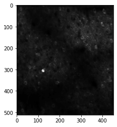

```python
plt.imshow(dataset.average_projection, cmap = 'gray')
```

**behavior_session_id**

```python
dataset.behavior_session_id
```

```
880784794
```

**cell_specimen_table**

```python
dataset.cell_specimen_table
```

| cell_specimen_id | cell_roi_id | height | mask_image_plane | max_correction_down | max_correction_left | max_correction_right | max_correction_up | roi_mask | valid_roi | width | x | y |
| --- | --- | --- | --- | --- | --- | --- | --- | --- | --- | --- | --- | --- |
| 1082539673 | 1080863440 | 20 | 1 | 16.0 | 16.0 | 9.0 | 20.0 | [[False, False, False, False, False, False, Fa... | False | 14 | 321 | 68 |
| 1082522451 | 1080863444 | 15 | 1 | 16.0 | 16.0 | 9.0 | 20.0 | [[False, False, False, False, False, False, Fa... | False | 13 | 31 | 76 |
| 1082569298 | 1080863449 | 15 | 1 | 16.0 | 16.0 | 9.0 | 20.0 | [[False, False, False, False, False, False, Fa... | False | 12 | 2 | 35 |
| 1082503407 | 1080863454 | 22 | 1 | 16.0 | 16.0 | 9.0 | 20.0 | [[False, False, False, False, False, False, Fa... | False | 16 | 275 | 47 |
| 1082569385 | 1080863460 | 16 | 1 | 16.0 | 16.0 | 9.0 | 20.0 | [[False, False, False, False, False, False, Fa... | False | 18 | 138 | 9 |
| ... | ... | ... | ... | ... | ... | ... | ... | ... | ... | ... | ... | ... |
| 1082530044 | 1080864257 | 24 | 2 | 16.0 | 16.0 | 9.0 | 20.0 | [[False, False, False, False, False, False, Fa... | True | 17 | 400 | 17 |
| 1082503446 | 1080864264 | 17 | 2 | 16.0 | 16.0 | 9.0 | 20.0 | [[False, False, False, False, False, False, Fa... | False | 23 | 326 | 65 |
| 1082572068 | 1080864269 | 18 | 2 | 16.0 | 16.0 | 9.0 | 20.0 | [[False, False, False, False, False, False, Fa... | False | 15 | 260 | 33 |
| 1082524828 | 1080864275 | 21 | 2 | 16.0 | 16.0 | 9.0 | 20.0 | [[False, False, False, False, False, False, Fa... | True | 15 | 43 | 106 |
| 1082503210 | 1080864280 | 17 | 2 | 16.0 | 16.0 | 9.0 | 20.0 | [[False, False, False, False, False, False, Fa... | True | 16 | 304 | 89 |

230 rows × 12 columns

```python
dataset.cell_specimen_table.keys()
```

```
Index(['cell_roi_id', 'height', 'mask_image_plane', 'max_correction_down',
       'max_correction_left', 'max_correction_right', 'max_correction_up',
       'roi_mask', 'valid_roi', 'width', 'x', 'y'],
      dtype='object')
```

**corrected_fluorescence_traces**

```python
dataset.corrected_fluorescence_traces
```

| cell_specimen_id | cell_roi_id | corrected_fluorescence |
| --- | --- | --- |
| 1082539673 | 1080863440 | [3205.544698795699, 2900.656041242715, 3136.93... |
| 1082522451 | 1080863444 | [2119.849935848636, 2242.6722404202587, 2147.7... |
| 1082569298 | 1080863449 | [nan, nan, nan, nan, nan, nan, nan, nan, nan, ... |
| 1082503407 | 1080863454 | [3016.7864387314457, 2610.855649694406, 2841.1... |
| 1082569385 | 1080863460 | [nan, nan, nan, nan, nan, nan, nan, nan, nan, ... |
| ... | ... | ... |
| 1082530044 | 1080864257 | [2826.126917717041, 2741.340287503335, 2698.61... |
| 1082503446 | 1080864264 | [2435.836013325677, 2491.601212002388, 2341.04... |
| 1082572068 | 1080864269 | [1897.70011475456, 2201.5434015789024, 1927.24... |
| 1082524828 | 1080864275 | [2032.899563380223, 2153.6328345838697, 2221.5... |
| 1082503210 | 1080864280 | [3643.0099310045266, 4006.205121963685, 3869.4... |

230 rows × 2 columns

**dff_traces**

```python
dataset.dff_traces
```

| cell_specimen_id | cell_roi_id | dff |
| --- | --- | --- |
| 1082539673 | 1080863440 | [0.22915050387382507, 0.05610385909676552, 0.1... |
| 1082522451 | 1080863444 | [0.23017016053199768, 0.29636380076408386, 0.2... |
| 1082569298 | 1080863449 | [nan, nan, nan, nan, nan, nan, nan, nan, nan, ... |
| 1082503407 | 1080863454 | [0.5031132698059082, 0.20701280236244202, 0.29... |
| 1082569385 | 1080863460 | [nan, nan, nan, nan, nan, nan, nan, nan, nan, ... |
| ... | ... | ... |
| 1082530044 | 1080864257 | [0.2701435685157776, 0.18289685249328613, 0.15... |
| 1082503446 | 1080864264 | [0.2671900689601898, 0.251191645860672, 0.1482... |
| 1082572068 | 1080864269 | [0.15561053156852722, 0.3199875056743622, 0.08... |
| 1082524828 | 1080864275 | [0.16684333980083466, 0.23877158761024475, 0.2... |
| 1082503210 | 1080864280 | [0.18325850367546082, 0.2723626494407654, 0.20... |

230 rows × 2 columns

**events**

```python
dataset.events
```

| cell_specimen_id | cell_roi_id | events | filtered_events | lambda | noise_std |
| --- | --- | --- | --- | --- | --- |
| 1082569445 | 1080863467 | [0.0, 0.0, 0.0, 0.0, 0.0, 0.0, 0.0, 0.0, 0.0, ... | [0.0, 0.0, 0.0, 0.0, 0.0, 0.0, 0.0, 0.0, 0.0, ... | 0.0473 | 0.063508 |
| 1082511467 | 1080863499 | [0.0, 0.0, 0.0, 0.0, 0.0, 0.0, 0.0, 0.0, 0.0, ... | [0.0, 0.0, 0.0, 0.0, 0.0, 0.0, 0.0, 0.0, 0.0, ... | 0.0481 | 0.064681 |
| 1082569734 | 1080863510 | [0.0, 0.0, 0.0, 0.0, 0.0, 0.0, 0.0, 0.0, 0.0, ... | [0.0, 0.0, 0.0, 0.0, 0.0, 0.0, 0.0, 0.0, 0.0, ... | 0.0368 | 0.056529 |
| 1082517454 | 1080863519 | [0.0, 0.0, 0.0, 0.0, 0.0, 0.0, 0.0, 0.0, 0.0, ... | [0.0, 0.0, 0.0, 0.0, 0.0, 0.0, 0.0, 0.0, 0.0, ... | 0.0398 | 0.058218 |
| 1082510283 | 1080863525 | [0.0, 0.0, 0.0, 0.0, 0.0, 0.0, 0.0, 0.0, 0.0, ... | [0.0, 0.0, 0.0, 0.0, 0.0, 0.0, 0.0, 0.0, 0.0, ... | 0.0536 | 0.067797 |
| ... | ... | ... | ... | ... | ... |
| 1082523453 | 1080864239 | [0.0, 0.0, 0.0, 0.0, 0.0, 0.0, 0.0, 0.0, 0.0, ... | [0.0, 0.0, 0.0, 0.0, 0.0, 0.0, 0.0, 0.0, 0.0, ... | 0.0502 | 0.065251 |
| 1082571988 | 1080864245 | [0.0, 0.0, 0.0, 0.0, 0.0, 0.0, 0.0, 0.0, 0.0, ... | [0.0, 0.0, 0.0, 0.0, 0.0, 0.0, 0.0, 0.0, 0.0, ... | 0.0466 | 0.063685 |
| 1082530044 | 1080864257 | [0.0, 0.0, 0.0, 0.0, 0.0, 0.0, 0.0, 0.0, 0.0, ... | [0.0, 0.0, 0.0, 0.0, 0.0, 0.0, 0.0, 0.0, 0.0, ... | 0.0294 | 0.050189 |
| 1082524828 | 1080864275 | [0.0, 0.0, 0.0, 0.0, 0.0, 0.0, 0.0, 0.0, 0.0, ... | [0.0, 0.0, 0.0, 0.0, 0.0, 0.0, 0.0, 0.0, 0.0, ... | 0.0313 | 0.051591 |
| 1082503210 | 1080864280 | [0.0, 0.0, 0.0, 0.0, 0.0, 0.0, 0.0, 0.0, 0.0, ... | [0.0, 0.0, 0.0, 0.0, 0.0, 0.0, 0.0, 0.0, 0.0, ... | 0.0296 | 0.052737 |

98 rows × 5 columns

```python
dataset.events.keys()
```

```
Index(['cell_roi_id', 'events', 'filtered_events', 'lambda', 'noise_std'], dtype='object')
```

**eye_tracking**

```python
dataset.eye_tracking
```

| frame | time | cr_area | eye_area | pupil_area | likely_blink | pupil_area_raw | cr_area_raw | eye_area_raw | cr_center_x | cr_center_y | ... | eye_center_x | eye_center_y | eye_height | eye_phi | eye_width | pupil_center_x | pupil_center_y | pupil_height | pupil_phi | pupil_width |
| --- | --- | --- | --- | --- | --- | --- | --- | --- | --- | --- | --- | --- | --- | --- | --- | --- | --- | --- | --- | --- | --- |
| 0 | 0.19240 | 191.414719 | 74958.793840 | 7609.880604 | False | 7609.880604 | 191.414719 | 74958.793840 | 374.884758 | 260.960312 | ... | 391.057156 | 257.252300 | 142.790813 | -0.002772 | 167.098461 | 382.332302 | 260.648219 | 47.479317 | 0.365607 | 49.216869 |
| 1 | 0.20297 | 198.723103 | 75210.042227 | 7496.761777 | False | 7496.761777 | 198.723103 | 75210.042227 | 375.031247 | 260.972804 | ... | 391.019782 | 257.541076 | 142.977048 | 0.010009 | 167.440161 | 382.225398 | 260.892945 | 47.618926 | 0.401105 | 48.849702 |
| 2 | 0.20668 | 190.839965 | 75209.271045 | 7515.602619 | False | 7515.602619 | 190.839965 | 75209.271045 | 374.615903 | 260.986891 | ... | 391.442654 | 257.852767 | 142.806634 | 0.023677 | 167.638252 | 381.776789 | 260.947388 | 46.896224 | 0.236995 | 48.911048 |
| 3 | 0.22400 | 237.710314 | 75122.082320 | 7625.961935 | False | 7625.961935 | 237.710314 | 75122.082320 | 373.634173 | 261.167573 | ... | 390.152522 | 257.771840 | 142.646415 | 0.020185 | 167.631984 | 382.013177 | 260.745734 | 47.293132 | 0.523014 | 49.268845 |
| 4 | 0.24016 | 190.811487 | 75368.881848 | 7498.766414 | False | 7498.766414 | 190.811487 | 75368.881848 | 374.463326 | 261.355921 | ... | 390.650551 | 258.052264 | 142.568154 | 0.014105 | 168.275028 | 381.629086 | 260.842422 | 47.067909 | 0.222462 | 48.856233 |
| ... | ... | ... | ... | ... | ... | ... | ... | ... | ... | ... | ... | ... | ... | ... | ... | ... | ... | ... | ... | ... | ... |
| 271811 | 4530.71100 | NaN | NaN | NaN | True | 10613.025713 | 151.236180 | 68327.898774 | 370.547915 | 262.504902 | ... | 388.090554 | 258.740831 | 133.903399 | 0.031878 | 162.426389 | 371.404092 | 266.584119 | 55.447403 | 0.009794 | 58.122552 |
| 271812 | 4530.72783 | NaN | NaN | NaN | True | 10239.543587 | 152.512904 | 67392.367562 | 369.734290 | 262.511500 | ... | 388.609486 | 259.070774 | 132.876674 | 0.015440 | 161.440351 | 371.157539 | 266.164762 | 55.077065 | 0.162880 | 57.090699 |
| 271813 | 4530.74475 | NaN | NaN | NaN | True | 10967.884918 | 154.895802 | 65664.827832 | 370.374547 | 266.192806 | ... | 388.972660 | 261.573153 | 130.810120 | 0.025344 | 159.787055 | 372.501917 | 272.514771 | 55.995268 | 0.318203 | 59.086261 |
| 271814 | 4530.76110 | NaN | NaN | NaN | True | 10707.273882 | 143.640206 | 66501.557078 | 370.305961 | 266.270005 | ... | 387.666637 | 260.899343 | 131.893954 | 0.026230 | 160.493354 | 369.991952 | 270.038161 | 55.503544 | 0.410863 | 58.380058 |
| 271815 | 4530.77822 | NaN | NaN | NaN | True | 10710.408947 | 145.082197 | 67308.808693 | 370.231437 | 265.690645 | ... | 387.898013 | 261.305369 | 132.409820 | 0.024575 | 161.808688 | 370.337110 | 270.390679 | 55.414139 | 0.439191 | 58.388604 |

271816 rows × 23 columns

```python
dataset.eye_tracking.keys()
```

```
Index(['time', 'cr_area', 'eye_area', 'pupil_area', 'likely_blink',
       'pupil_area_raw', 'cr_area_raw', 'eye_area_raw', 'cr_center_x',
       'cr_center_y', 'cr_height', 'cr_phi', 'cr_width', 'eye_center_x',
       'eye_center_y', 'eye_height', 'eye_phi', 'eye_width', 'pupil_center_x',
       'pupil_center_y', 'pupil_height', 'pupil_phi', 'pupil_width'],
      dtype='object')
```

**eye_tracking_rig_geometry**

```python
dataset.eye_tracking_rig_geometry
```

```
{'camera_position_mm': [102.8, 74.7, 31.6],
 'led_position': [246.0, 92.3, 52.6],
 'monitor_position_mm': [118.6, 86.2, 31.6],
 'camera_rotation_deg': [0.0, 0.0, 2.8],
 'monitor_rotation_deg': [0.0, 0.0, 0.0],
 'equipment': 'CAM2P.3'}
```

**get_rolling_performance_df**

```python
dataset.get_rolling_performance_df()
```

| trials_id | reward_rate | hit_rate_raw | hit_rate | false_alarm_rate_raw | false_alarm_rate | rolling_dprime |
| --- | --- | --- | --- | --- | --- | --- |
| 0 | NaN | NaN | NaN | NaN | NaN | NaN |
| 1 | NaN | NaN | NaN | NaN | NaN | NaN |
| 2 | NaN | NaN | NaN | NaN | NaN | NaN |
| 3 | NaN | NaN | NaN | NaN | NaN | NaN |
| 4 | NaN | NaN | NaN | NaN | NaN | NaN |
| ... | ... | ... | ... | ... | ... | ... |
| 679 | 2.884243 | 0.689655 | 0.689655 | 0.153846 | 0.153846 | 1.514949 |
| 680 | 2.914287 | NaN | NaN | NaN | NaN | NaN |
| 681 | 2.976293 | 0.689655 | 0.689655 | 0.153846 | 0.153846 | 1.514949 |
| 682 | 3.057613 | NaN | NaN | NaN | NaN | NaN |
| 683 | 3.108573 | 0.693182 | 0.693182 | 0.166667 | 0.166667 | 1.472311 |

684 rows × 6 columns

```python
dataset.get_rolling_performance_df().keys()
```

```
Index(['reward_rate', 'hit_rate_raw', 'hit_rate', 'false_alarm_rate_raw',
       'false_alarm_rate', 'rolling_dprime'],
      dtype='object')
```

**get_performance_metrics**

```python
dataset.get_performance_metrics()
```

```
{'trial_count': 684,
 'go_trial_count': 201,
 'catch_trial_count': 29,
 'hit_trial_count': 125,
 'miss_trial_count': 76,
 'false_alarm_trial_count': 4,
 'correct_reject_trial_count': 25,
 'auto_rewarded_trial_count': 5,
 'rewarded_trial_count': 130,
 'total_reward_count': 130,
 'total_reward_volume': 0.9,
 'maximum_reward_rate': 4.260480503077539,
 'engaged_trial_count': 396,
 'mean_hit_rate': 0.5926560469575076,
 'mean_hit_rate_uncorrected': 0.5904726408439706,
 'mean_hit_rate_engaged': 0.6019700966228269,
 'mean_false_alarm_rate': 0.14658570897701334,
 'mean_false_alarm_rate_uncorrected': 0.1491651826434435,
 'mean_false_alarm_rate_engaged': 0.14973052988677987,
 'mean_dprime': 1.389807512671435,
 'mean_dprime_engaged': 1.4155292622680602,
 'max_dprime': 1.9426239851075426,
 'max_dprime_engaged': 1.9426239851075426}
```

**licks**

```python
dataset.licks
```

|  | time | frame |
| --- | --- | --- |
| 0 | 7.39533 | 64 |
| 1 | 9.84700 | 211 |
| 2 | 14.60086 | 496 |
| 3 | 15.65172 | 559 |
| 4 | 19.63829 | 798 |
| ... | ... | ... |
| 3359 | 4462.69631 | 267164 |
| 3360 | 4489.35140 | 268762 |
| 3361 | 4490.00191 | 268801 |
| 3362 | 4491.05279 | 268864 |
| 3363 | 4492.68742 | 268962 |

3364 rows × 2 columns

**max_projection**

```python
dataset.max_projection
```

```
Image(data=array([[1.        , 1.        , 1.        , ..., 0.05490196, 0.05490196,
        0.06666667],
       [0.09019608, 0.11372549, 0.06666667, ..., 0.11372549, 0.09019608,
        0.05490196],
       [0.07843138, 0.06666667, 0.05490196, ..., 0.11372549, 0.09019608,
        0.06666667],
       ...,
       [0.05490196, 0.10196079, 0.10196079, ..., 0.20392157, 0.20392157,
        0.1254902 ],
       [0.09019608, 0.15686275, 0.11372549, ..., 0.1254902 , 0.1254902 ,
        0.09019608],
       [0.13333334, 0.15686275, 0.11372549, ..., 0.1254902 , 0.11372549,
        0.10196079]], dtype=float32), spacing=(0.00078125, 0.00078125), unit='mm')
```

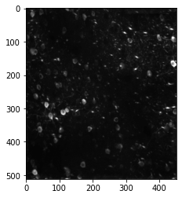

```python
plt.imshow(dataset.max_projection, cmap = "gray")
```

**metadata**

```python
dataset.metadata
```

```
{'behavior_session_id': 880784794,
 'ophys_session_id': 880753403,
 'ophys_experiment_id': 880961028,
 'experiment_container_id': 869781307,
 'ophys_frame_rate': 31.0,
 'stimulus_frame_rate': 60.0,
 'targeted_structure': 'VISp',
 'imaging_depth': 175,
 'session_type': 'OPHYS_6_images_B',
 'experiment_datetime': Timestamp('2019-06-04 20:08:17+0000', tz='UTC'),
 'full_genotype': 'Slc17a7-IRES2-Cre/wt;Camk2a-tTA/wt;Ai93(TITL-GCaMP6f)/wt',
 'reporter_line': ['Ai93(TITL-GCaMP6f)'],
 'driver_line': ['Camk2a-tTA', 'Slc17a7-IRES2-Cre'],
 'LabTracks_ID': 450471,
 'behavior_session_uuid': UUID('4d4dfd3e-e1bf-4ad8-9775-1273ce7e5189'),
 'imaging_plane_group': None,
 'imaging_plane_group_count': 0,
 'rig_name': 'CAM2P.3',
 'sex': 'F',
 'age': '21 wks',
 'excitation_lambda': 910.0,
 'emission_lambda': 520.0,
 'indicator': 'GCAMP6f',
 'field_of_view_width': 452,
 'field_of_view_height': 512}
```

```python
dataset.metadata.keys()
```

[output not shown]

**motion_correction**

```python
dataset.motion_correction
```

|  | x | y |
| --- | --- | --- |
| 0 | 12 | -5 |
| 1 | 12 | -5 |
| 2 | 13 | -6 |
| 3 | 13 | -6 |
| 4 | 13 | -6 |
| ... | ... | ... |
| 140087 | -4 | 8 |
| 140088 | -4 | 8 |
| 140089 | -4 | 8 |
| 140090 | -3 | 8 |
| 140091 | -4 | 8 |

140092 rows × 2 columns

**ophys_experiment_id**

```python
dataset.ophys_experiment_id
```

```
880961028
```

**ophys_session_id**

```python
dataset.ophys_session_id
```

[output not shown]

**ophys_timestamps**

```python
dataset.ophys_timestamps
```

```
array([2.34106000e+00, 2.37337000e+00, 2.40568000e+00, ...,
       4.53018277e+03, 4.53021509e+03, 4.53024741e+03])
```

**raw_running_speed**

```python
dataset.raw_running_speed
```

|  | timestamps | speed |
| --- | --- | --- |
| 0 | 6.32806 | NaN |
| 1 | 6.34459 | NaN |
| 2 | 6.36127 | NaN |
| 3 | 6.37789 | 18.833131 |
| 4 | 6.39459 | 6.417842 |
| ... | ... | ... |
| 270056 | 4510.93565 | 3.756925 |
| 270057 | 4510.95236 | 1.605989 |
| 270058 | 4510.96904 | 0.000000 |
| 270059 | 4510.98569 | -1.073962 |
| 270060 | 4511.00241 | -0.534595 |

270061 rows × 2 columns

**rewards**

```python
dataset.rewards
```

| timestamps | volume | autorewarded |
| --- | --- | --- |
| 310.97570 | 0.005 | True |
| 318.48182 | 0.005 | True |
| 328.23975 | 0.005 | True |
| 337.24713 | 0.005 | True |
| 353.76057 | 0.005 | True |
| ... | ... | ... |
| 3857.83613 | 0.007 | False |
| 3870.76335 | 0.007 | False |
| 3878.10270 | 0.007 | False |
| 3896.95138 | 0.007 | False |
| 3906.94286 | 0.007 | False |

130 rows × 2 columns

**running_speed**

```python
dataset.running_speed
```

|  | timestamps | speed |
| --- | --- | --- |
| 0 | 6.32806 | 0.092765 |
| 1 | 6.34459 | 3.032155 |
| 2 | 6.36127 | 5.880546 |
| 3 | 6.37789 | 8.535666 |
| 4 | 6.39459 | 10.910884 |
| ... | ... | ... |
| 270056 | 4510.93565 | 0.874885 |
| 270057 | 4510.95236 | 0.578200 |
| 270058 | 4510.96904 | 0.227750 |
| 270059 | 4510.98569 | -0.163964 |
| 270060 | 4511.00241 | -0.576190 |

270061 rows × 2 columns

**segmentation_mask_image**

```python
dataset.segmentation_mask_image
```

```
Image(data=array([[0, 0, 0, ..., 0, 0, 0],
       [0, 0, 0, ..., 0, 0, 0],
       [0, 0, 0, ..., 1, 0, 0],
       ...,
       [0, 0, 0, ..., 0, 0, 0],
       [0, 0, 0, ..., 0, 0, 0],
       [0, 0, 0, ..., 0, 0, 0]]), spacing=(0.00078125, 0.00078125), unit='mm')
```

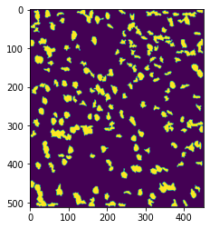

```python
plt.imshow(dataset.segmentation_mask_image)
```

**stimulus_presentations**

```python
dataset.stimulus_presentations
```

| stimulus_presentations_id | duration | end_frame | image_index | image_name | image_set | index | omitted | start_frame | start_time | stop_time |
| --- | --- | --- | --- | --- | --- | --- | --- | --- | --- | --- |
| 0 | 0.25022 | 18001.0 | 0 | im000 | Natural_Images_Lum_Matched_set_ophys_6_2017.07.14 | 0 | False | 17986 | 306.33857 | 306.58879 |
| 1 | 0.25013 | 18046.0 | 0 | im000 | Natural_Images_Lum_Matched_set_ophys_6_2017.07.14 | 1 | False | 18031 | 307.08924 | 307.33937 |
| 2 | 0.25020 | 18091.0 | 0 | im000 | Natural_Images_Lum_Matched_set_ophys_6_2017.07.14 | 2 | False | 18076 | 307.83981 | 308.09001 |
| 3 | 0.25021 | 18136.0 | 0 | im000 | Natural_Images_Lum_Matched_set_ophys_6_2017.07.14 | 3 | False | 18121 | 308.59041 | 308.84062 |
| 4 | 0.25019 | 18181.0 | 0 | im000 | Natural_Images_Lum_Matched_set_ophys_6_2017.07.14 | 4 | False | 18166 | 309.34103 | 309.59122 |
| ... | ... | ... | ... | ... | ... | ... | ... | ... | ... | ... |
| 4797 | 0.25024 | 233866.0 | 7 | im035 | Natural_Images_Lum_Matched_set_ophys_6_2017.07.14 | 4627 | False | 233851 | 3907.02623 | 3907.27647 |
| 4798 | 0.25021 | 233911.0 | 7 | im035 | Natural_Images_Lum_Matched_set_ophys_6_2017.07.14 | 4628 | False | 233896 | 3907.77687 | 3908.02708 |
| 4799 | 0.25020 | 233956.0 | 7 | im035 | Natural_Images_Lum_Matched_set_ophys_6_2017.07.14 | 4629 | False | 233941 | 3908.52749 | 3908.77769 |
| 4800 | 0.25021 | 234001.0 | 7 | im035 | Natural_Images_Lum_Matched_set_ophys_6_2017.07.14 | 4630 | False | 233986 | 3909.27810 | 3909.52831 |
| 4801 | 0.25024 | 234046.0 | 7 | im035 | Natural_Images_Lum_Matched_set_ophys_6_2017.07.14 | 4631 | False | 234031 | 3910.02868 | 3910.27892 |

4802 rows × 10 columns

```python
dataset.stimulus_presentations.keys()
```

```
Index(['duration', 'end_frame', 'image_index', 'image_name', 'image_set',
       'index', 'omitted', 'start_frame', 'start_time', 'stop_time'],
      dtype='object')
```

**stimulus_templates**

```python
dataset.stimulus_templates
```

[output not shown]

[output cut: 21 more lines]

[output not shown]

```python
dataset.stimulus_templates.keys()
```

```
dict_keys(['im000', 'im106', 'im075', 'im073', 'im045', 'im054', 'im031', 'im035'])
```

```python
first_image = list(dataset.stimulus_templates.keys())[0]
```

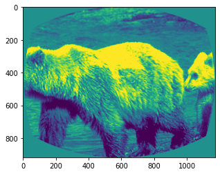

```python
plt.imshow(dataset.stimulus_templates[first_image])
```

**stimulus_timestamps**

```python
dataset.stimulus_timestamps
```

```
array([   6.32806,    6.34459,    6.36127, ..., 4510.96904, 4510.98569,
       4511.00241])
```

**task_parameters**

```python
dataset.task_parameters
```

```
{'blank_duration_sec': [0.5, 0.5],
 'stimulus_duration_sec': 0.25,
 'omitted_flash_fraction': 0.05,
 'response_window_sec': [0.15, 0.75],
 'reward_volume': 0.007,
 'auto_reward_volume': 0.005,
 'session_type': 'OPHYS_6_images_B',
 'stimulus': 'images',
 'stimulus_distribution': 'geometric',
 'task': 'change detection',
 'n_stimulus_frames': 69480}
```

**trials**

```python
dataset.trials
```

| trials_id | lick_times | reward_time | reward_volume | hit | false_alarm | miss | stimulus_change | aborted | go | catch | ... | correct_reject | start_time | stop_time | trial_length | response_time | change_frame | change_time | response_latency | initial_image_name | change_image_name |
| --- | --- | --- | --- | --- | --- | --- | --- | --- | --- | --- | --- | --- | --- | --- | --- | --- | --- | --- | --- | --- | --- |
| 0 | [306.95575, 307.15592] | NaN | 0.000 | False | False | False | False | True | False | False | ... | False | 306.32190 | 307.47284 | 1.15094 | NaN | NaN | NaN | NaN | im000 | im000 |
| 1 | [311.24258, 311.40937, 311.55948, 311.69293, 3... | 310.97570 | 0.005 | False | False | False | True | False | False | False | ... | False | 307.82313 | 315.07905 | 7.25592 | 311.24258 | 18255.0 | 310.847088 | 0.395492 | im000 | im073 |
| 2 | [318.74872, 318.83209, 318.98223, 319.09897, 3... | 318.48182 | 0.005 | False | False | False | True | False | False | False | ... | False | 315.32925 | 322.58517 | 7.25592 | 318.74872 | 18705.0 | 318.353228 | 0.395492 | im073 | im035 |
| 3 | [323.40249] | NaN | 0.000 | False | False | False | False | True | False | False | ... | False | 322.83537 | 323.71942 | 0.88405 | NaN | NaN | NaN | NaN | im035 | im035 |
| 4 | [328.52334, 328.60674, 328.70683, 328.84027, 3... | 328.23975 | 0.005 | False | False | False | True | False | False | False | ... | False | 324.33659 | 332.34313 | 8.00654 | 328.52334 | 19290.0 | 328.111188 | 0.412152 | im035 | im073 |
| ... | ... | ... | ... | ... | ... | ... | ... | ... | ... | ... | ... | ... | ... | ... | ... | ... | ... | ... | ... | ... | ... |
| 679 | [3887.5437] | NaN | 0.000 | False | False | True | True | False | True | False | ... | False | 3882.23937 | 3890.99649 | 8.75712 | 3887.54370 | 232635.0 | 3886.764548 | 0.779152 | im054 | im031 |
| 680 | [3893.18163] | NaN | 0.000 | False | False | False | False | True | False | False | ... | False | 3891.24672 | 3893.49857 | 2.25185 | NaN | NaN | NaN | NaN | im031 | im031 |
| 681 | [3896.95138, 3897.05145, 3897.21824, 3897.3016... | 3896.95138 | 0.007 | True | False | False | True | False | True | False | ... | False | 3893.49857 | 3900.75448 | 7.25591 | 3896.95138 | 233220.0 | 3896.522548 | 0.428832 | im031 | im054 |
| 682 | [3902.20564] | NaN | 0.000 | False | False | False | False | True | False | False | ... | False | 3901.00468 | 3902.52259 | 1.51791 | NaN | NaN | NaN | NaN | im054 | im054 |
| 683 | [3906.94286, 3907.0763, 3907.3265, 3907.42659,... | 3906.94286 | 0.007 | True | False | False | True | False | True | False | ... | False | 3903.25652 | 3910.51245 | 7.25593 | 3906.94286 | 233805.0 | 3906.280498 | 0.662362 | im054 | im035 |

684 rows × 21 columns

```python
dataset.trials.keys()
```

```
Index(['lick_times', 'reward_time', 'reward_volume', 'hit', 'false_alarm',
       'miss', 'stimulus_change', 'aborted', 'go', 'catch', 'auto_rewarded',
       'correct_reject', 'start_time', 'stop_time', 'trial_length',
       'response_time', 'change_frame', 'change_time', 'response_latency',
       'initial_image_name', 'change_image_name'],
      dtype='object')
```

## BehaviorSession

```python
from allensdk.brain_observatory.behavior.behavior_project_cache import BehaviorProjectCache
cache = BehaviorProjectCache.from_lims(manifest=loading.get_manifest_path())
behavior_sessions_table = cache.get_behavior_session_table().reset_index()
```

```
Getting behavior-only session data. This might take a while...
```

```python
#behavior_sessions that do have ophys_sessions & ophys_experiment
behavior_session_ids_1 = release_exps["behavior_session_id"].unique()

#behavior_sessions that may or may not have an accompanying ophys_session & ophys_experiment
behavior_session_ids_2 = behavior_sessions_table["behavior_session_id"].unique()
```

```python
behavior_session_id = behavior_session_ids[33]
behavior_dataset = BehaviorSession.from_lims(behavior_session_id)
```

### dataset attributes

```python
behavior_dataset.__dict__
```

```
{'api': <allensdk.brain_observatory.behavior.session_apis.data_io.behavior_lims_api.BehaviorLimsApi at 0x125522da148>,
 '_behavior_session_id': <allensdk.core.lazy_property.lazy_property.LazyProperty at 0x125553115c8>,
 '_licks': <allensdk.core.lazy_property.lazy_property.LazyProperty at 0x1254f891648>,
 '_rewards': <allensdk.core.lazy_property.lazy_property.LazyProperty at 0x125522da288>,
 '_running_speed': <allensdk.core.lazy_property.lazy_property.LazyProperty at 0x125522da548>,
 '_raw_running_speed': <allensdk.core.lazy_property.lazy_property.LazyProperty at 0x125522da808>,
 '_stimulus_presentations': <allensdk.core.lazy_property.lazy_property.LazyProperty at 0x125522dacc8>,
 '_stimulus_templates': <allensdk.core.lazy_property.lazy_property.LazyProperty at 0x125522dad08>,
 '_stimulus_timestamps': <allensdk.core.lazy_property.lazy_property.LazyProperty at 0x125522dad88>,
 '_task_parameters': <allensdk.core.lazy_property.lazy_property.LazyProperty at 0x125522dae48>,
 '_trials': <allensdk.core.lazy_property.lazy_property.LazyProperty at 0x125522daec8>,
 '_metadata': <allensdk.core.lazy_property.lazy_property.LazyProperty at 0x125522daf48>}
```

behavior_session_id  
licks  
metadata  
raw_running_speed  
rewards  
running_speed  
stimulus_presentations  
stimulus_templates  
stimulus_timestamps  
task_parameters  
trials

**behavior_session_id**

```python
behavior_dataset.behavior_session_id
```

```
901363879
```

**licks**

```python
behavior_dataset.licks
```

|  | timestamps | frame |
| --- | --- | --- |
| 0 | 3.468200 | 208 |
| 1 | 5.919903 | 355 |
| 2 | 6.070032 | 364 |
| 3 | 7.454312 | 447 |
| 4 | 16.694028 | 1001 |
| ... | ... | ... |
| 3890 | 4379.496799 | 262583 |
| 3891 | 4431.382938 | 265694 |
| 3892 | 4471.360782 | 268091 |
| 3893 | 4494.827126 | 269498 |
| 3894 | 4497.645758 | 269667 |

3895 rows × 2 columns

**metadata**

```python
behavior_dataset.metadata
```

```
{'rig_name': 'BEH.G-Box5',
 'sex': 'F',
 'age': 'P233',
 'stimulus_frame_rate': 60.0,
 'session_type': 'TRAINING_5_images_A_handoff_ready',
 'experiment_datetime': Timestamp('2019-07-08 13:10:44.381000+0000', tz='UTC'),
 'reporter_line': ['Ai148(TIT2L-GC6f-ICL-tTA2)'],
 'driver_line': ['Sst-IRES-Cre'],
 'LabTracks_ID': 457841,
 'full_genotype': 'Sst-IRES-Cre/wt;Ai148(TIT2L-GC6f-ICL-tTA2)/wt',
 'behavior_session_uuid': UUID('70e44c9a-8ba4-4701-9ab5-9a754d28a46e'),
 'behavior_session_id': 901363879}
```

**raw_running_speed**

```python
behavior_dataset.raw_running_speed
```

|  | timestamps | speed |
| --- | --- | --- |
| 0 | 0.000000 | NaN |
| 1 | 0.016170 | NaN |
| 2 | 0.032885 | NaN |
| 3 | 0.049545 | 0.000000 |
| 4 | 0.068043 | -0.964103 |
| ... | ... | ... |
| 269928 | 4501.998852 | 2.672947 |
| 269929 | 4502.015511 | 6.419928 |
| 269930 | 4502.032196 | 1.600747 |
| 269931 | 4502.048876 | 9.622857 |
| 269932 | 4502.065575 | 6.399431 |

269933 rows × 2 columns

**rewards**

```python
behavior_dataset.rewards
```

|  | volume | timestamps | autorewarded |
| --- | --- | --- | --- |
| 0 | 0.005 | 339.952536 | True |
| 1 | 0.005 | 369.256229 | True |
| 2 | 0.005 | 428.664288 | True |
| 3 | 0.005 | 461.703958 | True |
| 4 | 0.005 | 566.126592 | True |
| 5 | 0.007 | 614.460249 | False |
| 6 | 0.007 | 642.212874 | False |
| 7 | 0.007 | 746.652255 | False |
| 8 | 0.007 | 769.368055 | False |
| 9 | 0.007 | 964.520493 | False |
| 10 | 0.007 | 1010.135573 | False |
| 11 | 0.007 | 1072.428903 | False |
| 12 | 0.007 | 1118.994662 | False |
| 13 | 0.007 | 1139.975918 | False |
| 14 | 0.007 | 1257.574401 | False |
| 15 | 0.007 | 1313.846891 | False |
| 16 | 0.007 | 1484.398894 | False |
| 17 | 0.007 | 1508.549030 | False |
| 18 | 0.007 | 1522.959061 | False |
| 19 | 0.007 | 1579.581809 | False |
| 20 | 0.007 | 1632.685415 | False |
| 21 | 0.007 | 1683.620876 | False |
| 22 | 0.007 | 1726.650808 | False |
| 23 | 0.007 | 1741.544488 | False |
| 24 | 0.007 | 1804.721778 | False |
| 25 | 0.007 | 1919.034646 | False |
| 26 | 0.007 | 1939.382132 | False |
| 27 | 0.007 | 2021.239094 | False |
| 28 | 0.007 | 2087.468509 | False |
| 29 | 0.007 | 2175.996771 | False |
| 30 | 0.007 | 2260.288749 | False |
| 31 | 0.007 | 2299.365950 | False |
| 32 | 0.007 | 2357.873331 | False |
| 33 | 0.007 | 2388.094369 | False |
| 34 | 0.007 | 2455.107597 | False |
| 35 | 0.007 | 2537.047992 | False |
| 36 | 0.007 | 2636.233681 | False |
| 37 | 0.007 | 2728.297703 | False |
| 38 | 0.007 | 2857.220758 | False |
| 39 | 0.007 | 2962.127093 | False |
| 40 | 0.007 | 2970.132673 | False |
| 41 | 0.007 | 3067.934050 | False |
| 42 | 0.007 | 3129.510222 | False |
| 43 | 0.007 | 3149.740964 | False |
| 44 | 0.007 | 3165.551971 | False |
| 45 | 0.007 | 3191.803567 | False |
| 46 | 0.007 | 3209.132289 | False |
| 47 | 0.007 | 3264.087189 | False |
| 48 | 0.007 | 3295.692517 | False |
| 49 | 0.007 | 3322.677965 | False |
| 50 | 0.007 | 3339.222809 | False |
| 51 | 0.007 | 3390.475159 | False |
| 52 | 0.007 | 3399.314640 | False |
| 53 | 0.007 | 3418.878239 | False |
| 54 | 0.007 | 3710.180926 | False |
| 55 | 0.007 | 3770.189321 | False |
| 56 | 0.007 | 3777.294263 | False |
| 57 | 0.007 | 3826.511842 | False |

**running_speed**

```python
behavior_dataset.running_speed
```

|  | timestamps | speed |
| --- | --- | --- |
| 0 | 0.000000 | 0.005497 |
| 1 | 0.016170 | -0.078912 |
| 2 | 0.032885 | -0.150530 |
| 3 | 0.049545 | -0.197086 |
| 4 | 0.068043 | -0.211169 |
| ... | ... | ... |
| 269928 | 4501.998852 | 4.471499 |
| 269929 | 4502.015511 | 4.712808 |
| 269930 | 4502.032196 | 5.122367 |
| 269931 | 4502.048876 | 5.655478 |
| 269932 | 4502.065575 | 6.255330 |

269933 rows × 2 columns

**stimulus_presentations**

```python
behavior_dataset.stimulus_presentations
```

| stimulus_presentations_id | duration | end_frame | image_index | image_name | image_set | index | omitted | start_frame | start_time | stop_time |
| --- | --- | --- | --- | --- | --- | --- | --- | --- | --- | --- |
| 0 | 0.250170 | 18001.0 | 0 | im065 | Natural_Images_Lum_Matched_set_training_2017.0... | 0 | False | 17986.0 | 299.974610 | 300.224779 |
| 1 | 0.250152 | 18046.0 | 0 | im065 | Natural_Images_Lum_Matched_set_training_2017.0... | 1 | False | 18031.0 | 300.725140 | 300.975292 |
| 2 | 0.250214 | 18091.0 | 0 | im065 | Natural_Images_Lum_Matched_set_training_2017.0... | 2 | False | 18076.0 | 301.475602 | 301.725816 |
| 3 | 0.250221 | 18136.0 | 0 | im065 | Natural_Images_Lum_Matched_set_training_2017.0... | 3 | False | 18121.0 | 302.226121 | 302.476343 |
| 4 | 0.250213 | 18181.0 | 0 | im065 | Natural_Images_Lum_Matched_set_training_2017.0... | 4 | False | 18166.0 | 302.976657 | 303.226870 |
| ... | ... | ... | ... | ... | ... | ... | ... | ... | ... | ... |
| 4786 | 0.250169 | 233737.0 | 4 | im063 | Natural_Images_Lum_Matched_set_training_2017.0... | 4786 | False | 233722.0 | 3898.145052 | 3898.395221 |
| 4787 | 0.250204 | 233782.0 | 4 | im063 | Natural_Images_Lum_Matched_set_training_2017.0... | 4787 | False | 233767.0 | 3898.895530 | 3899.145733 |
| 4788 | 0.250187 | 233827.0 | 4 | im063 | Natural_Images_Lum_Matched_set_training_2017.0... | 4788 | False | 233812.0 | 3899.646096 | 3899.896283 |
| 4789 | 0.250172 | 233872.0 | 4 | im063 | Natural_Images_Lum_Matched_set_training_2017.0... | 4789 | False | 233857.0 | 3900.396578 | 3900.646750 |
| 4790 | 0.250111 | 233917.0 | 4 | im063 | Natural_Images_Lum_Matched_set_training_2017.0... | 4790 | False | 233902.0 | 3901.147156 | 3901.397267 |

4791 rows × 10 columns

**stimulus_templates**

```python
behavior_dataset.stimulus_templates
```

[output not shown]

[output cut: 21 more lines]

[output not shown]

**stimulus_timestamps**

```python
behavior_dataset.stimulus_timestamps
```

```
array([0.00000000e+00, 1.61699560e-02, 3.28848101e-02, ...,
       4.50203220e+03, 4.50204888e+03, 4.50206558e+03])
```

**task_parameters**

```python
behavior_dataset.task_parameters
```

[output not shown]

**trials**

```python
behavior_dataset.trials
```

| trials_id | lick_times | reward_time | reward_volume | hit | false_alarm | miss | stimulus_change | aborted | go | catch | ... | correct_reject | start_time | stop_time | trial_length | response_time | change_frame | change_time | response_latency | initial_image_name | change_image_name |
| --- | --- | --- | --- | --- | --- | --- | --- | --- | --- | --- | --- | --- | --- | --- | --- | --- | --- | --- | --- | --- | --- |
| 0 | [300.3915843432769, 300.5583505984396] | NaN | 0.0 | False | False | False | False | True | False | False | ... | False | 299.957932 | 300.875236 | 0.917304 | NaN | NaN | NaN | NaN | im065 | im065 |
| 1 | [303.49372202623636, 303.67717931233346] | NaN | 0.0 | False | False | False | False | True | False | False | ... | False | 301.458971 | 303.994077 | 2.535106 | NaN | NaN | NaN | NaN | im065 | im065 |
| 2 | [306.54582235310227, 306.695956306532] | NaN | 0.0 | False | False | False | False | True | False | False | ... | False | 304.461044 | 306.996117 | 2.535073 | NaN | NaN | NaN | NaN | im065 | im065 |
| 3 | [311.1323669757694, 311.28248541615903, 311.44... | NaN | 0.0 | False | False | False | False | True | False | False | ... | False | 307.463111 | 311.766163 | 4.303053 | NaN | NaN | NaN | NaN | im065 | im065 |
| 4 | [316.3360694637522] | NaN | 0.0 | False | False | False | False | True | False | False | ... | False | 311.982964 | 316.636301 | 4.653337 | NaN | NaN | NaN | NaN | im065 | im065 |
| ... | ... | ... | ... | ... | ... | ... | ... | ... | ... | ... | ... | ... | ... | ... | ... | ... | ... | ... | ... | ... | ... |
| 960 | [] | NaN | 0.0 | False | False | True | True | False | True | False | ... | False | 3854.581389 | 3866.356261 | 11.774871 | NaN | 231560.0 | 3862.107786 | inf | im077 | im063 |
| 961 | [] | NaN | 0.0 | False | False | True | True | False | True | False | ... | False | 3866.589759 | 3873.861476 | 7.271716 | NaN | 232010.0 | 3869.612968 | inf | im063 | im085 |
| 962 | [] | NaN | 0.0 | False | False | True | True | False | True | False | ... | False | 3874.111671 | 3885.135990 | 11.024319 | NaN | 232686.0 | 3880.887510 | inf | im085 | im061 |
| 963 | [] | NaN | 0.0 | False | False | True | True | False | True | False | ... | False | 3885.369493 | 3894.158935 | 8.789442 | NaN | 233226.0 | 3889.893773 | inf | im061 | im069 |
| 964 | [] | NaN | 0.0 | False | False | True | True | False | True | False | ... | False | 3894.375756 | 3901.664151 | 7.288395 | NaN | 233676.0 | 3897.398973 | inf | im069 | im063 |

965 rows × 21 columns